# Statistics_Group1_H2

### Viola-Tones

###### 1. All-in-One Model (Viola)

```r
#First, frequency_bin needs to be categorical:
data_group1_viola$frequency_bin <- as.factor(data_group1_viola$frequency_bin)

#Ancova without interaction:
ancova.viola.ele_freq_acoustics <- lm(elevation_diff ~ frequency_bin + centroid + flatness + roll_off, data = data_group1_viola)

#CHECKING FOR INTERACTION:
vif(ancova.viola.ele_freq_acoustics)
```

```
##                    GVIF Df GVIF^(1/(2*Df))
## frequency_bin 3383.5890  3        3.874624
## centroid      3390.3287  1       58.226529
## flatness       203.0564  1       14.249787
## roll_off       436.2148  1       20.885757
```

We have interaction for all parameters for this one, so lets continue using that model but with interaction terms.

```r
#lets do an interaction-model:
ancova.viola.ele_freqXacoustics <- lm(elevation_diff ~ frequency_bin * centroid * flatness *  roll_off, data = data_group1_viola)
```

Lets look at some diagnostic plots:

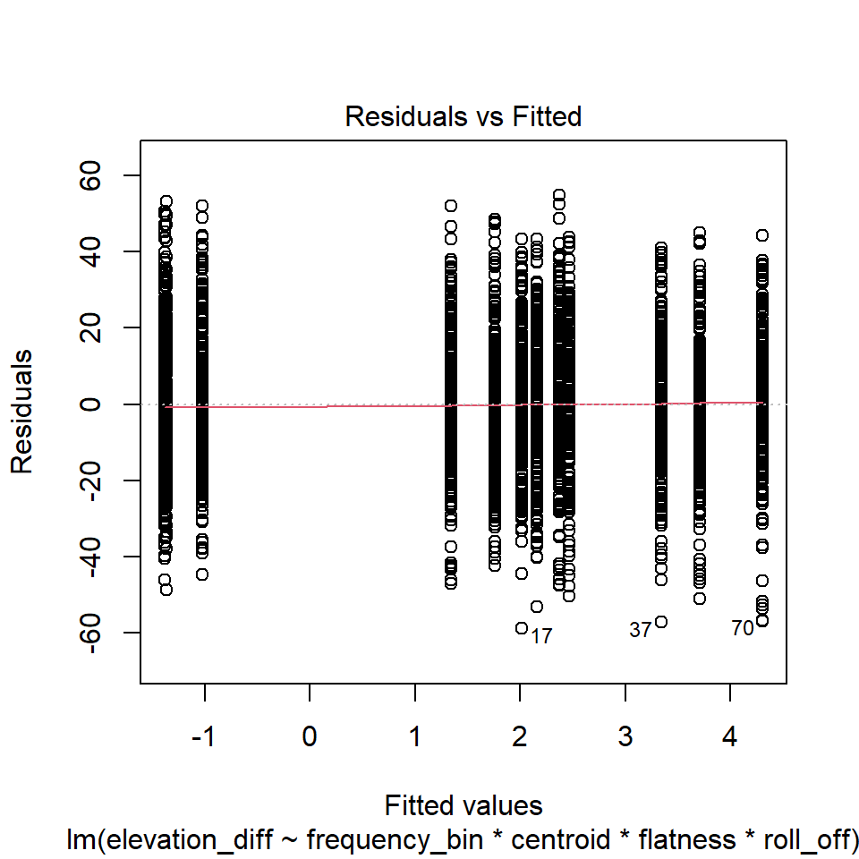

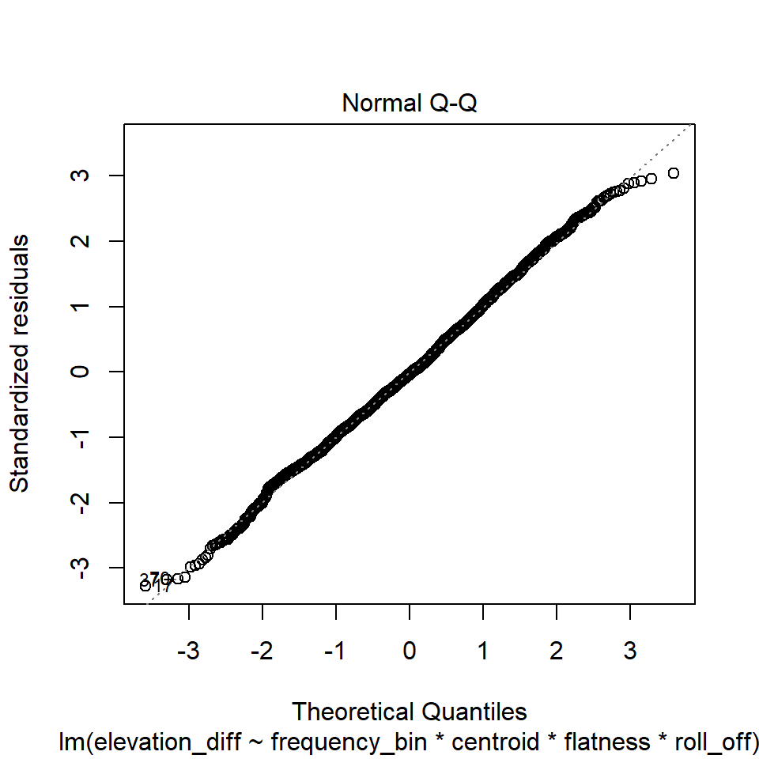

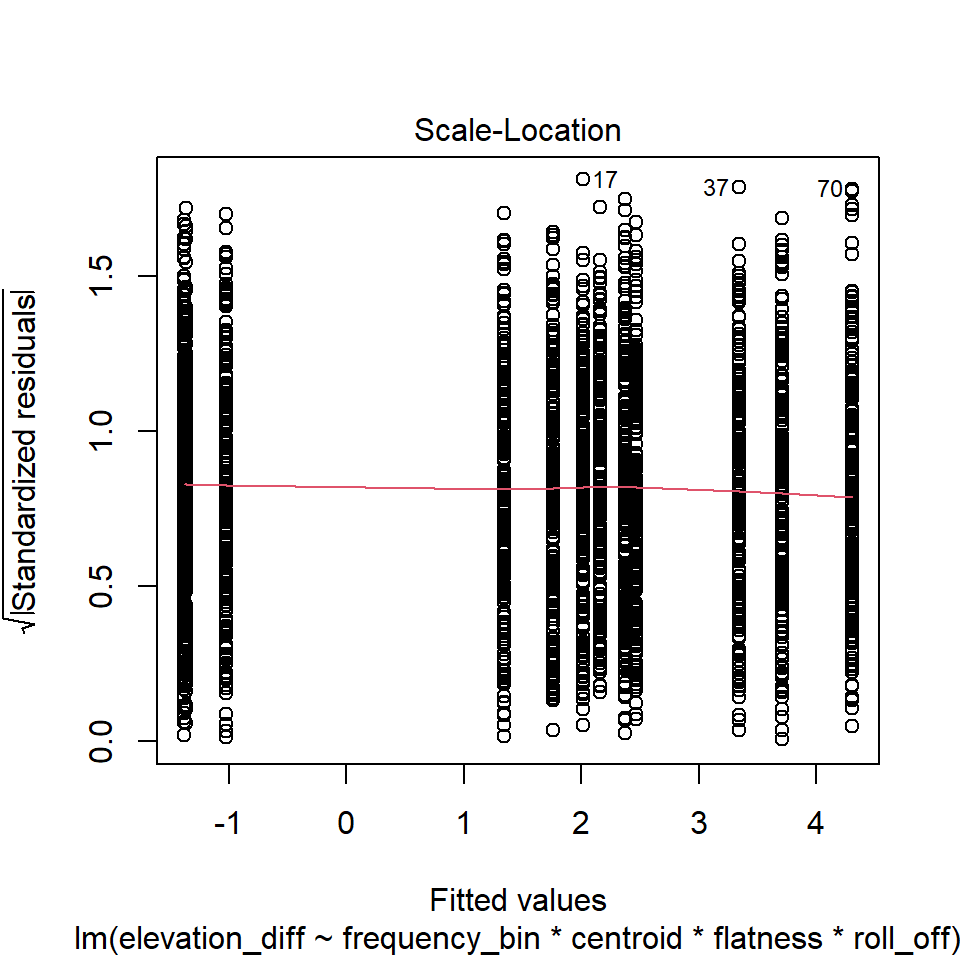

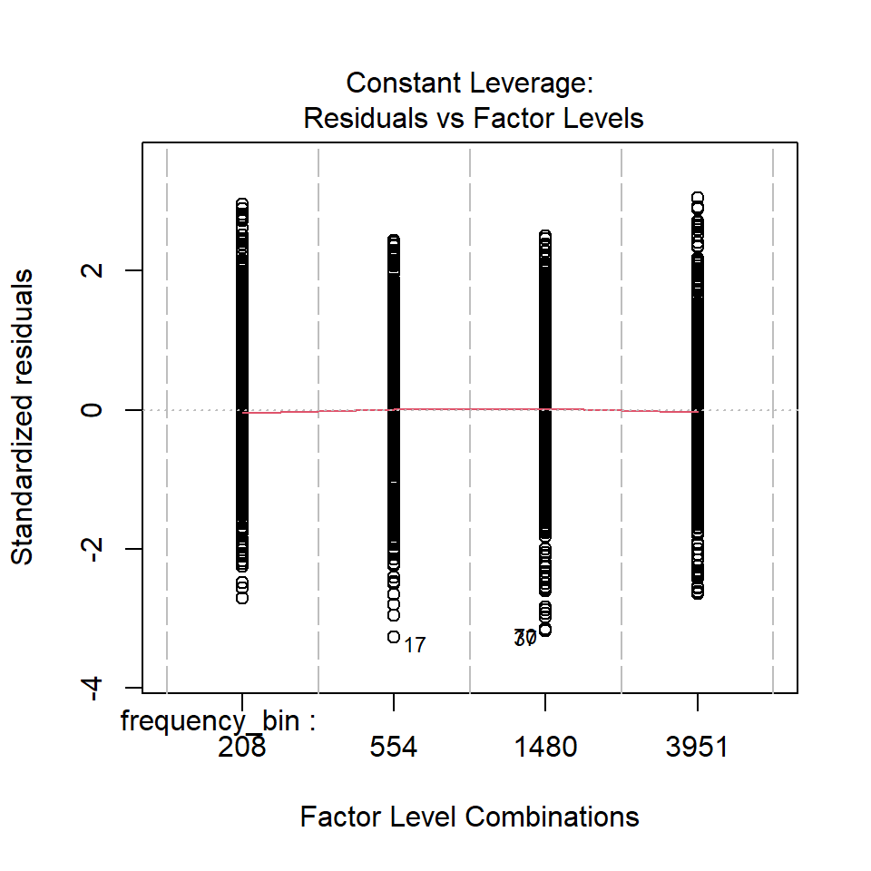

```r
#as always:
plot(ancova.viola.ele_freqXacoustics)
```

```r
#were good
```

And some statistics:

```r
#First the basic Anova stuff:
anova(ancova.viola.ele_freqXacoustics)
```

```
## Analysis of Variance Table
##
## Response: elevation_diff
##                          Df Sum Sq Mean Sq F value    Pr(>F)
## frequency_bin             3  10202  3400.6 10.4672 7.544e-07 ***
## centroid                  1     78    78.1  0.2404    0.6239
## flatness                  1      7     7.3  0.0225    0.8808
## roll_off                  1     44    44.4  0.1367    0.7116
## frequency_bin:centroid    3    154    51.5  0.1584    0.9243
## frequency_bin:flatness    2     22    10.8  0.0332    0.9673
## Residuals              3048 990243   324.9
## ---
## Signif. codes:  0 '***' 0.001 '**' 0.01 '*' 0.05 '.' 0.1 ' ' 1
```

```r
#Now our Post-Hoc thingy, i wanna try something:
emmeans(ancova.viola.ele_freqXacoustics, ~frequency_bin * centroid * flatness * roll_off)
```

```
##  frequency_bin centroid flatness roll_off emmean     SE   df lower.CL upper.CL
##  208               2849 0.000837     4543 nonEst     NA   NA       NA       NA
##  554               2849 0.000837     4543   6.93  44.00 3048    -79.3     93.1
##  1480              2849 0.000837     4543   4.13   8.12 3048    -11.8     20.1
##  3951              2849 0.000837     4543 -12.79 190.00 3048   -384.5    358.9
##
## Confidence level used: 0.95
```

The Anovatable tells us the same story as always (Pratt effect is present). The Post-Hoc thing shows us the means for each acoustic parameter in each frequency bin (which stays the same cause its the mean for our tested condition viola), as well as the confidence interval (Cl) and i believe the slope (emmean)

I also tried emtrends again but got nonsense fot that. I really have to find my way into the post-hoc tukey test universe.

### 2.1 Spectral Centroid (Viola):

```r
#Were working with the viola-tones now::
data_group1_viola$frequency_bin <- as.factor(data_group1_viola$frequency_bin)
#our model:
ancova_viola_ele_freqXcentroid <- lm(elevation_diff~frequency_bin*centroid, data=data_group1_viola)
```

Lets do my favorite thing in the world:

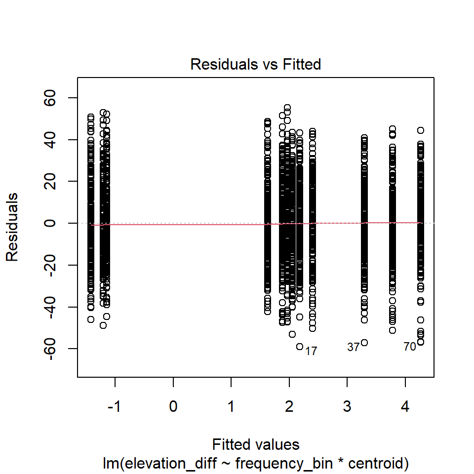

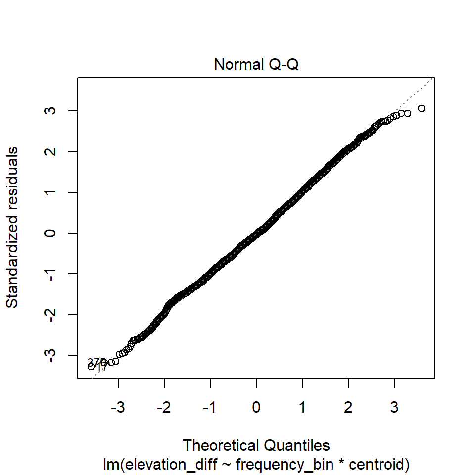

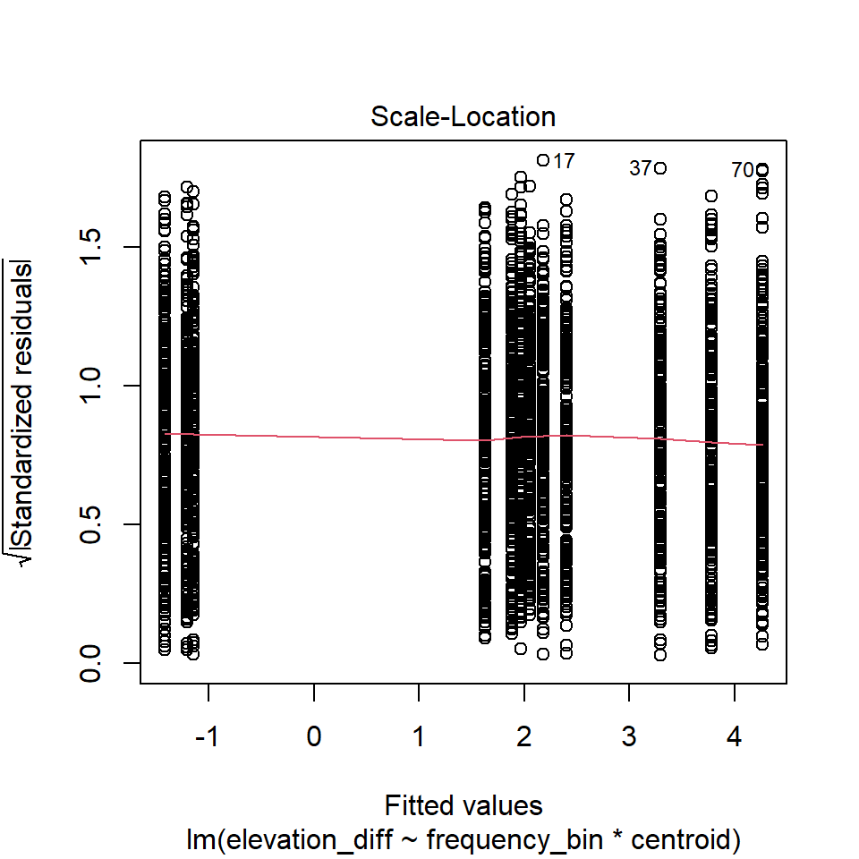

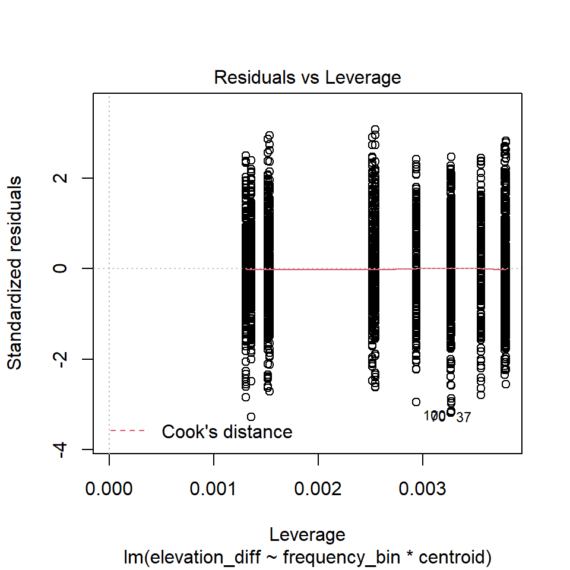

```r
#diagnostic plots-time:
plot(ancova_viola_ele_freqXcentroid)
```

```r
#now thats a normal distribution, Jesus Christ
```

More Stats:

```r
#ANOVA:
anova(ancova_viola_ele_freqXcentroid)
```

```
## Analysis of Variance Table
##
## Response: elevation_diff
##                          Df Sum Sq Mean Sq F value    Pr(>F)
## frequency_bin             3  10202  3400.6 10.4794 7.412e-07 ***
## centroid                  1     78    78.1  0.2407    0.6237
## frequency_bin:centroid    3     83    27.6  0.0850    0.9682
## Residuals              3052 990388   324.5
## ---
## Signif. codes:  0 '***' 0.001 '**' 0.01 '*' 0.05 '.' 0.1 ' ' 1
```

```r
#Post-Hoc:
emtrends(ancova_viola_ele_freqXcentroid,
         pairwise~frequency_bin, var="centroid")
```

```
## $emtrends
##  frequency_bin centroid.trend      SE   df lower.CL upper.CL
##  208                 0.001268 0.00699 3052 -0.01244  0.01498
##  554                 0.002384 0.01090 3052 -0.01893  0.02370
##  1480                0.005332 0.00880 3052 -0.01193  0.02260
##  3951                0.000699 0.00319 3052 -0.00556  0.00696
##
## Confidence level used: 0.95
##
## $contrasts
##  contrast                               estimate      SE   df t.ratio p.value
##  frequency_bin208 - frequency_bin554   -0.001117 0.01290 3052  -0.086  0.9998
##  frequency_bin208 - frequency_bin1480  -0.004065 0.01120 3052  -0.362  0.9838
##  frequency_bin208 - frequency_bin3951   0.000568 0.00769 3052   0.074  0.9999
##  frequency_bin554 - frequency_bin1480  -0.002948 0.01400 3052  -0.211  0.9967
##  frequency_bin554 - frequency_bin3951   0.001685 0.01130 3052   0.149  0.9988
##  frequency_bin1480 - frequency_bin3951  0.004633 0.00937 3052   0.495  0.9603
##
## P value adjustment: tukey method for comparing a family of 4 estimates
```

#### Results (Viola)

emtrends and emmeans-tables: The Post-Hoc results indicate, that if centroid were to predict elevation differences for the viola tones within each frequency_bin, there would be a positive relation (higher centroids result in higher elevation differences) for all frequency bins. However, we have no significance for any of those, so we can conclude: For our viola tones, the spectral centroid does not influence the presence and strength of the Pratts Effect either.

Proving that with the Interaction-plot:

[figure not shown]

Interaction Plot

```r
#for visual presentation:
interaction_plot_viola_centroid <-
  ggline(data_group1_viola, x = "centroid", y = "elevation_diff", color = "frequency_bin",
       add = c("mean_se"))
```

### 2.2 Spectral Flatness (Viola):

```r
#our model:
ancova.viola_ele_freqXflatness <- lm(elevation_diff~frequency_bin*flatness, data=data_group1_viola)
```

More Stats:

```r
#ANOVA for significance:
anova(ancova.viola_ele_freqXflatness)
```

```
## Analysis of Variance Table
##
## Response: elevation_diff
##                          Df Sum Sq Mean Sq F value    Pr(>F)
## frequency_bin             3  10202  3400.6 10.4799 7.407e-07 ***
## flatness                  1     79    79.5  0.2449    0.6207
## frequency_bin:flatness    3    122    40.5  0.1248    0.9455
## Residuals              3052 990348   324.5
## ---
## Signif. codes:  0 '***' 0.001 '**' 0.01 '*' 0.05 '.' 0.1 ' ' 1
```

```r
#Post-Hoc:
emtrends(ancova.viola_ele_freqXflatness,
         pairwise~frequency_bin, var="flatness")
```

```
## $emtrends
##  frequency_bin flatness.trend     SE   df lower.CL upper.CL
##  208                    29372 143000 3052  -251531   310275
##  554                    12537  43500 3052   -72744    97818
##  1480                    5137   8830 3052   -12173    22446
##  3951                     572   1450 3052    -2271     3415
##
## Confidence level used: 0.95
##
## $contrasts
##  contrast                              estimate     SE   df t.ratio p.value
##  frequency_bin208 - frequency_bin554      16835 150000 3052   0.112  0.9995
##  frequency_bin208 - frequency_bin1480     24235 144000 3052   0.169  0.9983
##  frequency_bin208 - frequency_bin3951     28800 143000 3052   0.201  0.9971
##  frequency_bin554 - frequency_bin1480      7400  44400 3052   0.167  0.9984
##  frequency_bin554 - frequency_bin3951     11965  43500 3052   0.275  0.9927
##  frequency_bin1480 - frequency_bin3951     4565   8950 3052   0.510  0.9567
##
## P value adjustment: tukey method for comparing a family of 4 estimates
```

#### Results (Viola)

Anova-Table: First statistics tell us, that the Pratts Effect is generally given (p= 7.407e-07 ***) and that flatness does not predict differences in elevation (p=0.6207), neither interacts with frequency_bin (p=0.9455) for the viola tones.

emtrends and emmeans-tables: These statistics show that if there was significance, which is unfortunately also not the case for viola tones, a higher value for flatness would predict higher elevation differences because the slopes (see flatness.trend) are positive for all frequency bins. They also seem to get less strong (slope number gets smaller) for rising frequency…

And interaction-plot:

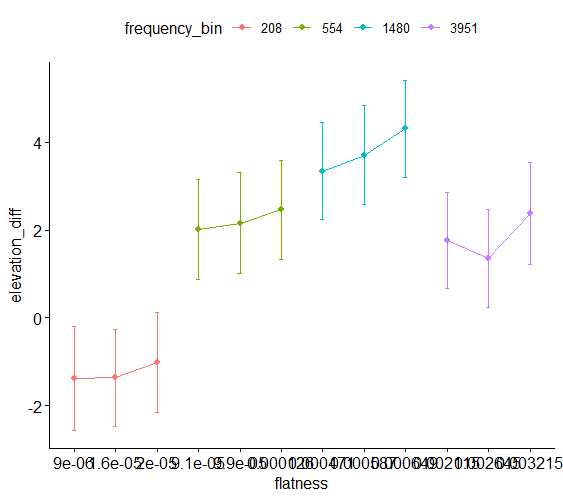

Interaction Plot

```r
#Last but not least:
interaction.plot_viola.flatness <-
  ggline(data_group1_viola, x = "flatness", y = "elevation_diff", color = "frequency_bin",
       add = c("mean_se"))
```

This aligns nicely with the Post-Hoc results again.

### 3. Spectral Roll-Off (Viola):

```r
#last but not least: Roll-off
data_group1_viola$frequency_bin <- as.factor(data_group1_viola$frequency_bin)

#our model:
ancova.viola.ele_freqXroll_off <- lm(elevation_diff~frequency_bin*roll_off, data=data_group1_viola)
```

More Stats:

```r
#ANOVA for significance:
anova(ancova.viola.ele_freqXroll_off)
```

```
## Analysis of Variance Table
##
## Response: elevation_diff
##                          Df Sum Sq Mean Sq F value    Pr(>F)
## frequency_bin             3  10202  3400.6 10.4805 7.401e-07 ***
## roll_off                  1     39    38.7  0.1191    0.7300
## frequency_bin:roll_off    3    222    74.1  0.2284    0.8767
## Residuals              3052 990288   324.5
## ---
## Signif. codes:  0 '***' 0.001 '**' 0.01 '*' 0.05 '.' 0.1 ' ' 1
```

```r
#Post-Hoc:
emtrends(ancova.viola.ele_freqXroll_off,
         pairwise~frequency_bin, var="roll_off")
```

```
## $emtrends
##  frequency_bin roll_off.trend      SE   df lower.CL upper.CL
##  208                 0.000371 0.00345 3052 -0.00639  0.00713
##  554                -0.001016 0.01030 3052 -0.02123  0.01919
##  1480                0.001944 0.00321 3052 -0.00435  0.00824
##  3951               -0.000781 0.00121 3052 -0.00315  0.00159
##
## Confidence level used: 0.95
##
## $contrasts
##  contrast                               estimate      SE   df t.ratio p.value
##  frequency_bin208 - frequency_bin554    0.001388 0.01090 3052   0.128  0.9993
##  frequency_bin208 - frequency_bin1480  -0.001573 0.00471 3052  -0.334  0.9872
##  frequency_bin208 - frequency_bin3951   0.001152 0.00366 3052   0.315  0.9892
##  frequency_bin554 - frequency_bin1480  -0.002961 0.01080 3052  -0.274  0.9928
##  frequency_bin554 - frequency_bin3951  -0.000235 0.01040 3052  -0.023  1.0000
##  frequency_bin1480 - frequency_bin3951  0.002725 0.00343 3052   0.794  0.8570
##
## P value adjustment: tukey method for comparing a family of 4 estimates
```

#### Results (viola)

Anova-table: In conclusion, again, the Pratts Effect is given (p= 7.401e-07 ***). However, there was no prediction of elevation differences by roll_off values (p= 0.7300) and roll_off also does not interact with frequency_bin for the viola tones (p= 0.8767).

And interaction-plot:

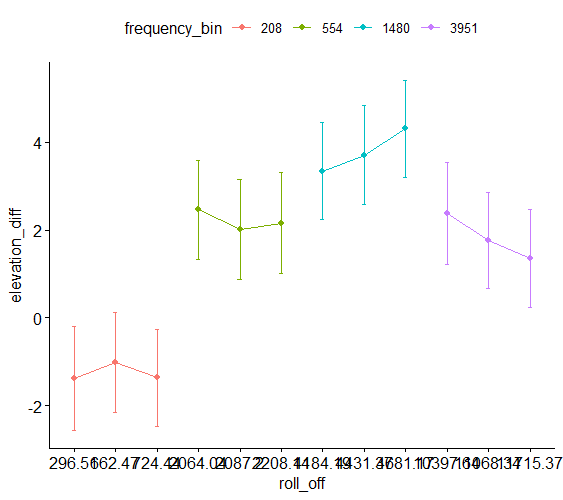

Interaction Plot

```r
#visualization:
interaction.plot_viola.roll_off <-
  ggline(data_group1_viola, x = "roll_off", y = "elevation_diff", color = "frequency_bin",
       add = c("mean_se"))
```

### Flute-Tones

#### 1. All-in-One Model (flute)

```r
#First, frequency_bin needs to be categorical:
data_group1_flute$frequency_bin <- as.factor(data_group1_flute$frequency_bin)

#Ancova without interaction:
ancova.flute.ele_freq_acoustics <- lm(elevation_diff ~ frequency_bin + centroid + flatness + roll_off, data = data_group1_flute)

#CHECKING FOR INTERACTION:
vif(ancova.flute.ele_freq_acoustics)
```

```
##                     GVIF Df GVIF^(1/(2*Df))
## frequency_bin 3675.92700  3        3.928510
## centroid      2734.78306  1       52.295153
## flatness        14.90417  1        3.860592
## roll_off      1980.18713  1       44.499294
```

We have interaction for all parameters for this one too, so lets continue using that model but with interaction terms.

```r
#lets do an interaction-model:
ancova.flute.ele_freqXacoustics <- lm(elevation_diff ~ frequency_bin * centroid * flatness *  roll_off, data = data_group1_flute)
```

Lets look at some diagnostic plots:

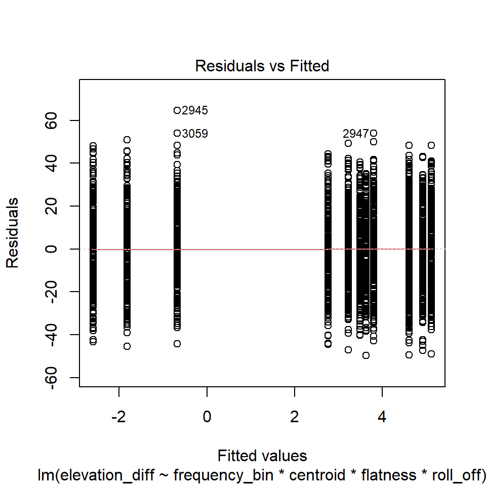

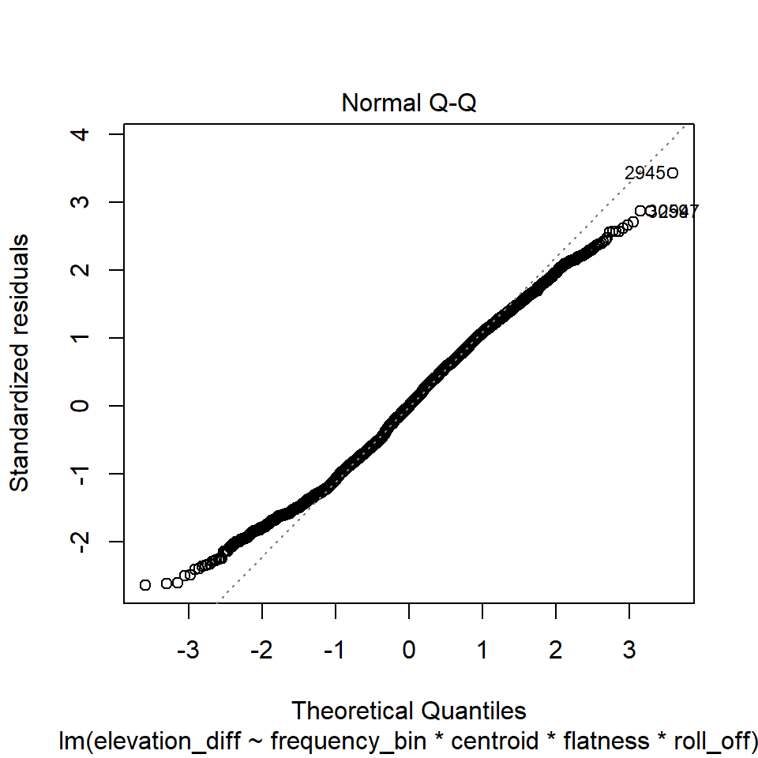

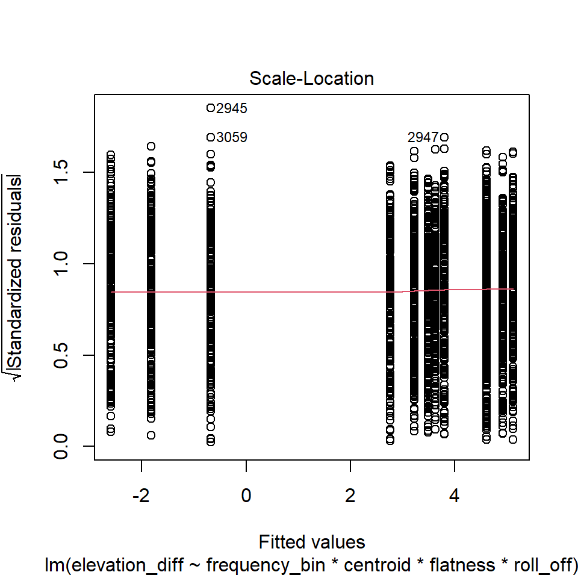

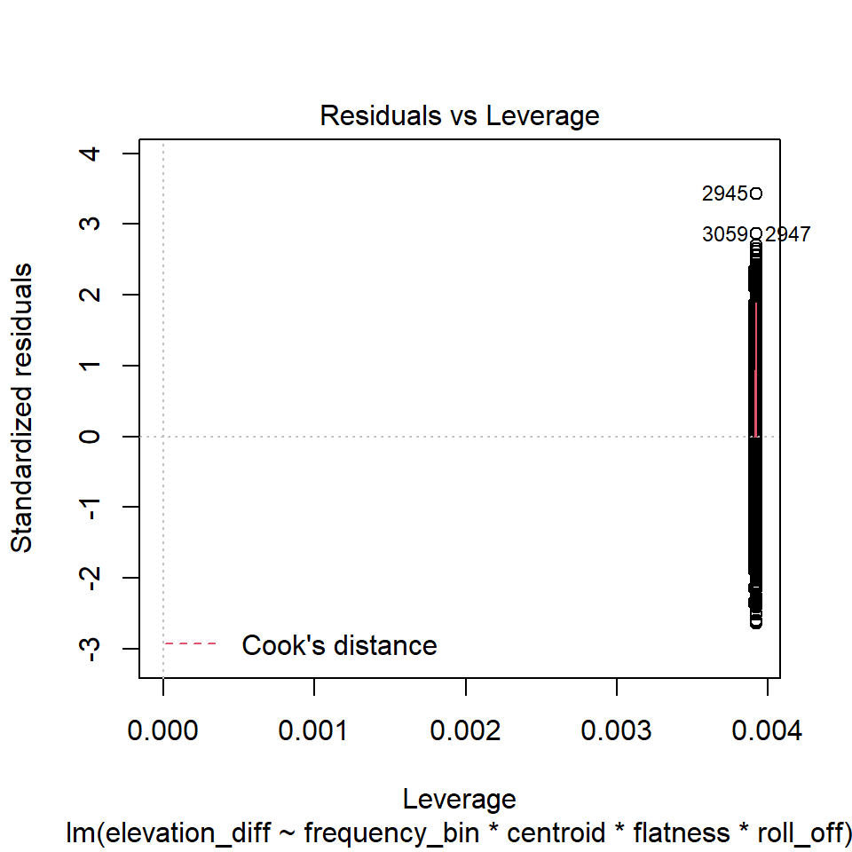

```r
#as always:
plot(ancova.flute.ele_freqXacoustics)
```

```r
#were doing okayish with this one
```

And some statistics:

```r
#First the basic Anova stuff:
anova(ancova.flute.ele_freqXacoustics)
```

```
## Analysis of Variance Table
##
## Response: elevation_diff
##                          Df  Sum Sq Mean Sq F value    Pr(>F)
## frequency_bin             3   19614  6538.0 18.3669 8.284e-12 ***
## centroid                  1     574   573.9  1.6121    0.2043
## flatness                  1     142   142.3  0.3998    0.5272
## roll_off                  1     101   100.6  0.2825    0.5951
## frequency_bin:centroid    3      96    32.1  0.0902    0.9655
## frequency_bin:flatness    2      88    44.2  0.1243    0.8831
## Residuals              3049 1085336   356.0
## ---
## Signif. codes:  0 '***' 0.001 '**' 0.01 '*' 0.05 '.' 0.1 ' ' 1
```

```r
#Post-Hoc thingy:
emmeans(ancova.flute.ele_freqXacoustics, ~frequency_bin * centroid * flatness * roll_off)
```

```
##  frequency_bin centroid flatness roll_off emmean    SE   df lower.CL upper.CL
##  208               1667 2.73e-05     1816 26.810 172.0 3049   -310.3    363.9
##  554               1667 2.73e-05     1816 nonEst    NA   NA       NA       NA
##  1480              1667 2.73e-05     1816 12.108  33.1 3049    -52.7     76.9
##  3951              1667 2.73e-05     1816 -0.144  19.0 3049    -37.4     37.1
##
## Confidence level used: 0.95
```

Same stuff as always. Pratt effect is there (p=8.284e-12 ***), but theres no significant effect on it by the acoustic parameters.

### 3.1 Spectral Centroid (Flute):

```r
#Were working with the viola-tones now::
data_group1_flute$frequency_bin <- as.factor(data_group1_flute$frequency_bin)

#our model:
ancova_flute_ele_freqXcentroid <- lm(elevation_diff~frequency_bin*centroid, data=data_group1_flute)
```

Lets do my favorite thing in the world:

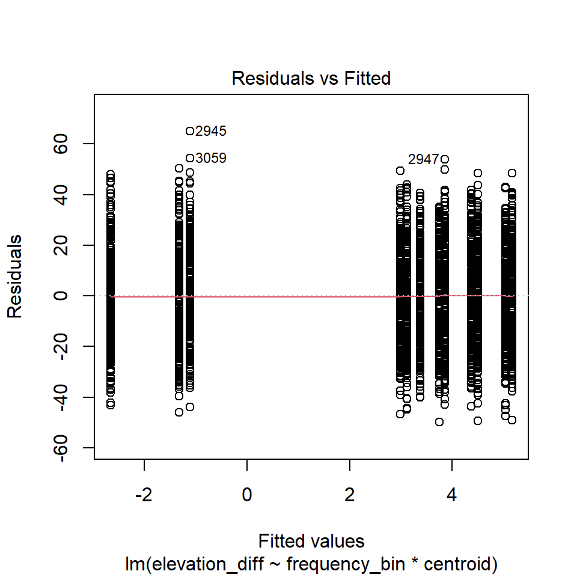

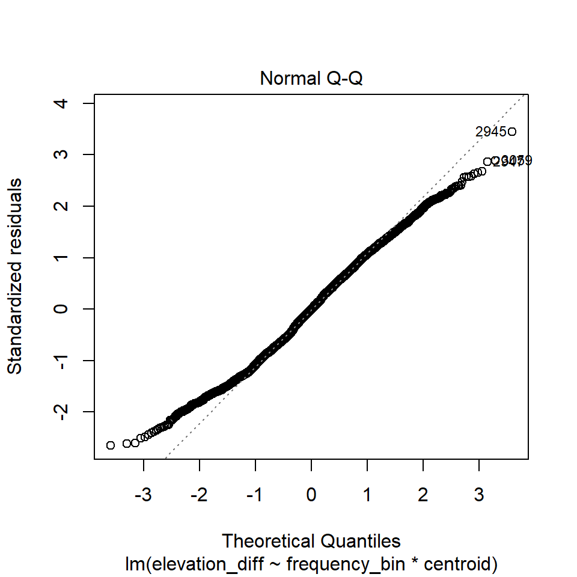

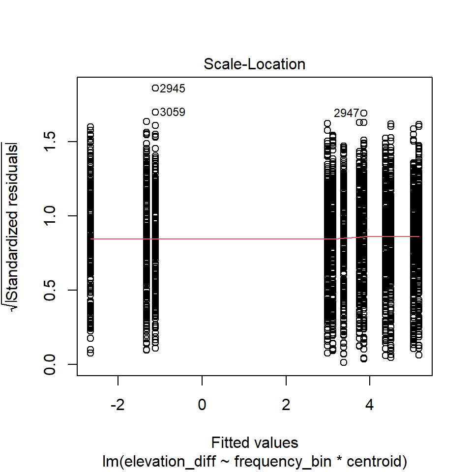

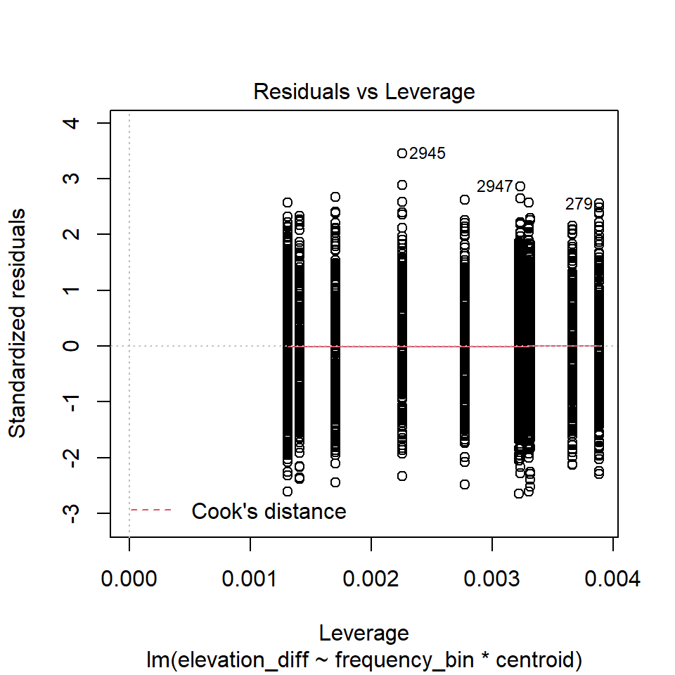

```r
#diagnostic plots-time:
plot(ancova_flute_ele_freqXcentroid)
```

```r
#normal distribution is a little funky
```

More Stats:

```r
#ANOVA:
anova(ancova_flute_ele_freqXcentroid)
```

```
## Analysis of Variance Table
##
## Response: elevation_diff
##                          Df  Sum Sq Mean Sq F value    Pr(>F)
## frequency_bin             3   19614  6538.0 18.3878 8.035e-12 ***
## centroid                  1     574   573.9  1.6140    0.2040
## frequency_bin:centroid    3     238    79.4  0.2233    0.8802
## Residuals              3053 1085525   355.6
## ---
## Signif. codes:  0 '***' 0.001 '**' 0.01 '*' 0.05 '.' 0.1 ' ' 1
```

```r
#Post-Hoc:
emtrends(ancova_flute_ele_freqXcentroid,
         pairwise~frequency_bin, var="centroid")
```

```
## $emtrends
##  frequency_bin centroid.trend      SE   df lower.CL upper.CL
##  208                  0.01125 0.01120 3053 -0.01064  0.03314
##  554                  0.00561 0.02370 3053 -0.04090  0.05213
##  1480                 0.00758 0.00967 3053 -0.01137  0.02653
##  3951                 0.00281 0.00363 3053 -0.00431  0.00993
##
## Confidence level used: 0.95
##
## $contrasts
##  contrast                              estimate     SE   df t.ratio p.value
##  frequency_bin208 - frequency_bin554    0.00564 0.0262 3053   0.215  0.9965
##  frequency_bin208 - frequency_bin1480   0.00367 0.0148 3053   0.249  0.9946
##  frequency_bin208 - frequency_bin3951   0.00844 0.0117 3053   0.719  0.8896
##  frequency_bin554 - frequency_bin1480  -0.00196 0.0256 3053  -0.077  0.9998
##  frequency_bin554 - frequency_bin3951   0.00280 0.0240 3053   0.117  0.9994
##  frequency_bin1480 - frequency_bin3951  0.00477 0.0103 3053   0.462  0.9673
##
## P value adjustment: tukey method for comparing a family of 4 estimates
```

#### Results (Flute)

emtrends and emmeans-tables: The Post-Hoc results indicate just like for the viola tones, that if centroid was to predict elevation differences, within each frequency_bin, there would be a positive relation (higher centroids result in higher elevation differences) for all frequency bins. However, we have no significance for any of those, so we can conclude: For our flute tones, the spectral centroid does not influence the presence and strength of the Pratts Effect either.

Proving that with the Interaction-plot:

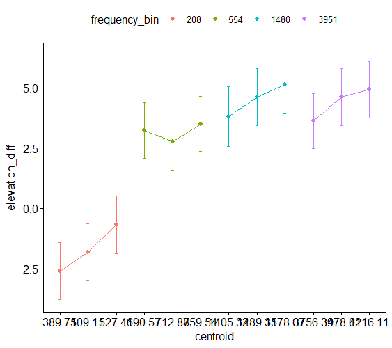

Interaction Plot

```r
#for visual presentation:
interaction_plot_flute_centroid <-
  ggline(data_group1_flute, x = "centroid", y = "elevation_diff", color = "frequency_bin",
       add = c("mean_se"))
```

Our results seem valid

### 3.2 Spectral Flatness (Flute):

```r
#our model:
ancova.flute_ele_freqXflatness <- lm(elevation_diff~frequency_bin*flatness, data=data_group1_flute)
```

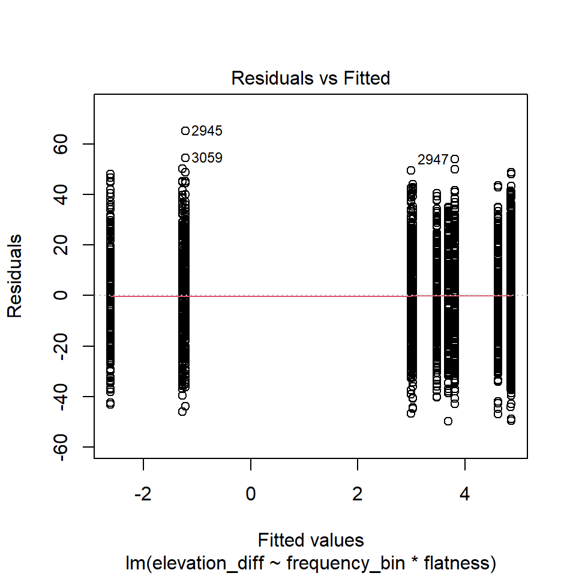

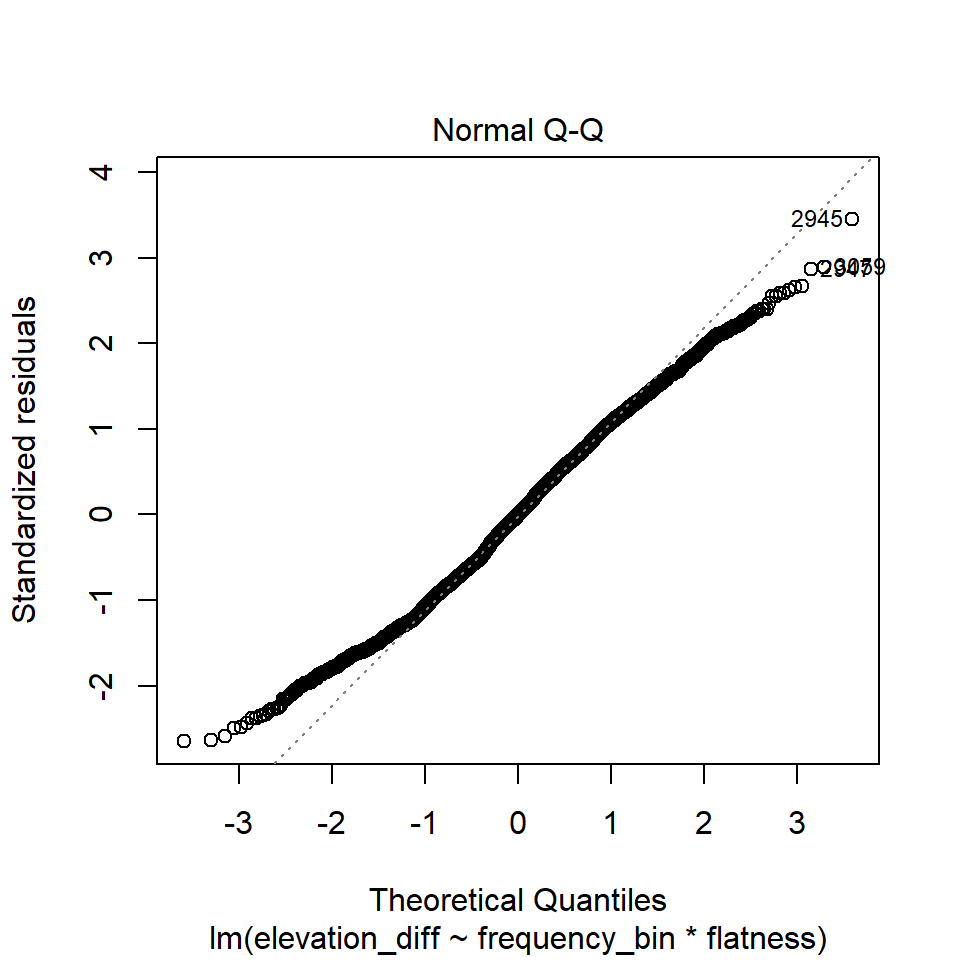

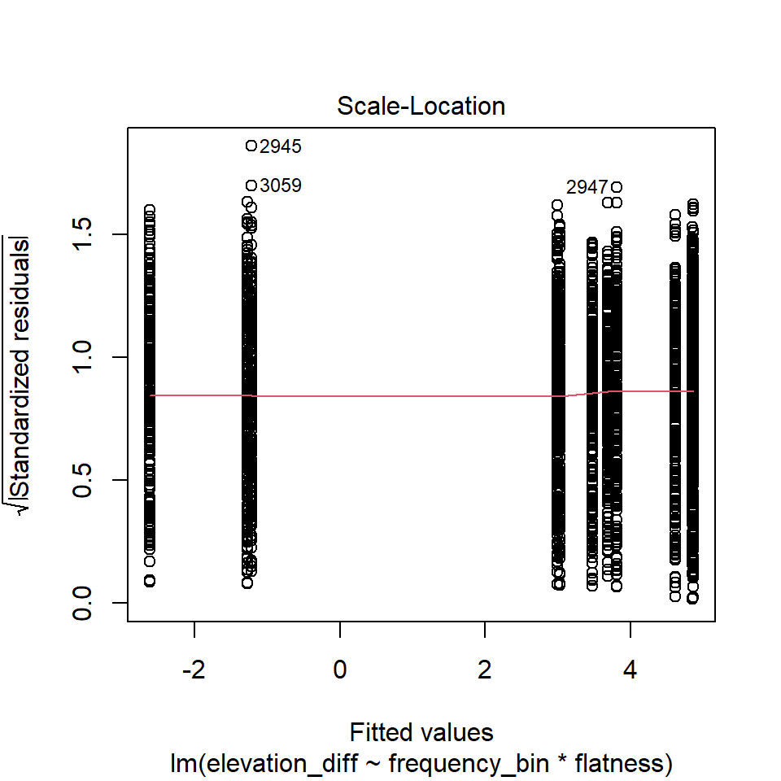

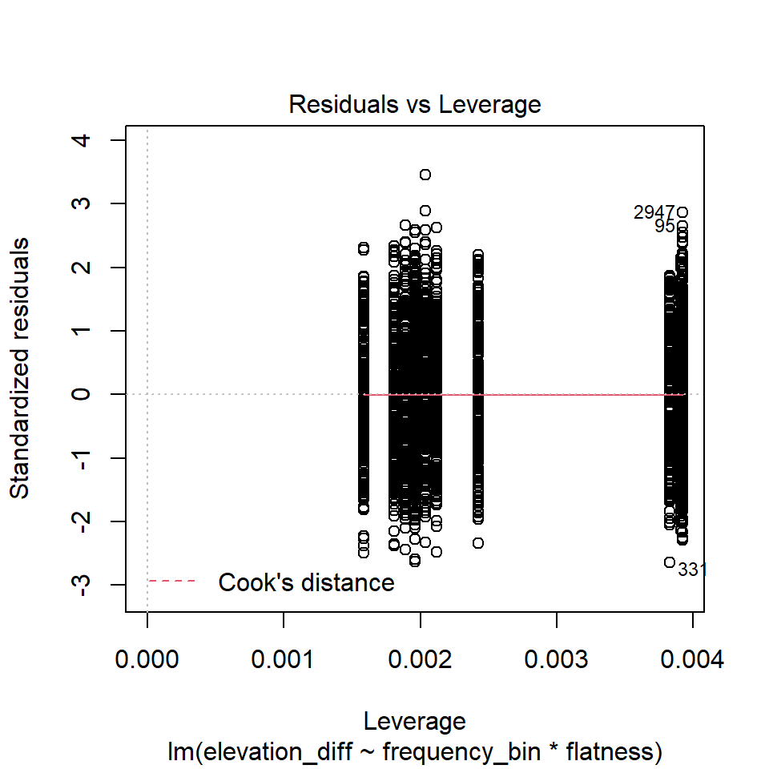

```r
#diagnostic plots-time:
plot(ancova.flute_ele_freqXflatness)
```

```r
#normal distribution is a little funky
```

More Stats:

```r
#ANOVA:
anova(ancova.flute_ele_freqXflatness)
```

```
## Analysis of Variance Table
##
## Response: elevation_diff
##                          Df  Sum Sq Mean Sq F value    Pr(>F)
## frequency_bin             3   19614  6538.0 18.3867 8.048e-12 ***
## flatness                  1     286   285.9  0.8041    0.3699
## frequency_bin:flatness    3     460   153.4  0.4313    0.7306
## Residuals              3053 1085591   355.6
## ---
## Signif. codes:  0 '***' 0.001 '**' 0.01 '*' 0.05 '.' 0.1 ' ' 1
```

```r
#Post-Hoc:
emtrends(ancova.flute_ele_freqXflatness,
         pairwise~frequency_bin, var="flatness")
```

```
## $emtrends
##  frequency_bin flatness.trend      SE   df lower.CL upper.CL
##  208                    51968   54500 3053   -54984   158920
##  554                    37191  115000 3053  -189068   263451
##  1480                 1058773 1450000 3053 -1776962  3894508
##  3951                 -234149  316000 3053  -852957   384659
##
## Confidence level used: 0.95
##
## $contrasts
##  contrast                              estimate      SE   df t.ratio p.value
##  frequency_bin208 - frequency_bin554      14776  128000 3053   0.116  0.9994
##  frequency_bin208 - frequency_bin1480  -1006805 1450000 3053  -0.696  0.8988
##  frequency_bin208 - frequency_bin3951    286117  320000 3053   0.893  0.8083
##  frequency_bin554 - frequency_bin1480  -1021581 1450000 3053  -0.704  0.8955
##  frequency_bin554 - frequency_bin3951    271340  336000 3053   0.807  0.8510
##  frequency_bin1480 - frequency_bin3951  1292922 1480000 3053   0.873  0.8186
##
## P value adjustment: tukey method for comparing a family of 4 estimates
```

#### Results (Flute)

Anova-table: First statistics tell us, that the Pratts Effect is generally given (p= 8.048e-12 ***). It also tells us that flatness does not predict differences in elevation (p= 0.3699) for the flute tones either, neither there is an interaction with frequency_bin (p= 0.7306).

emtrends and emmeans-tables: The Post-Hoc results indicate, that if flatness was to predict elevation differences, within almost all frequency_bins, there would be a positive relation (higher flatness result in higher elevation differences). Exeption would be the last one (3951 Hz). However, we have no significance for any of those, so we can conclude: For our flute tones, the spectral flatness does not influence the presence and strength of the Pratts Effect either.

Proving that with the Interaction-plot:

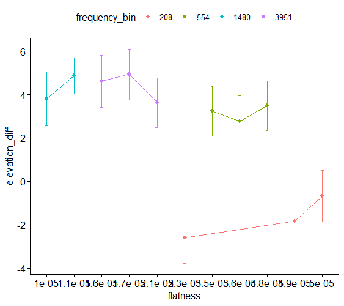

```r
#for visual presentation:
interaction_plot_flute_flatness <-
  ggline(data_group1_flute, x = "flatness", y = "elevation_diff", color = "frequency_bin",
       add = c("mean_se"))
```

### 3.3 Spectral Roll-Off (Flute):

```r
#our model:
ancova.flute_ele_freqXroll_off <- lm(elevation_diff~frequency_bin*roll_off, data=data_group1_flute)
```

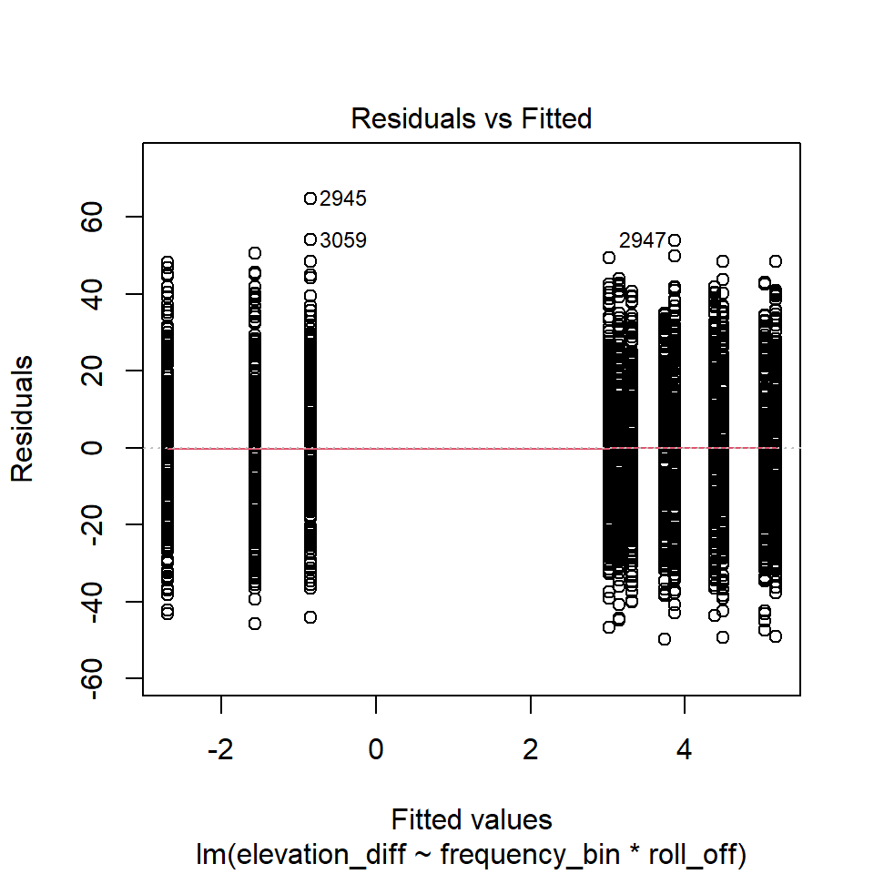

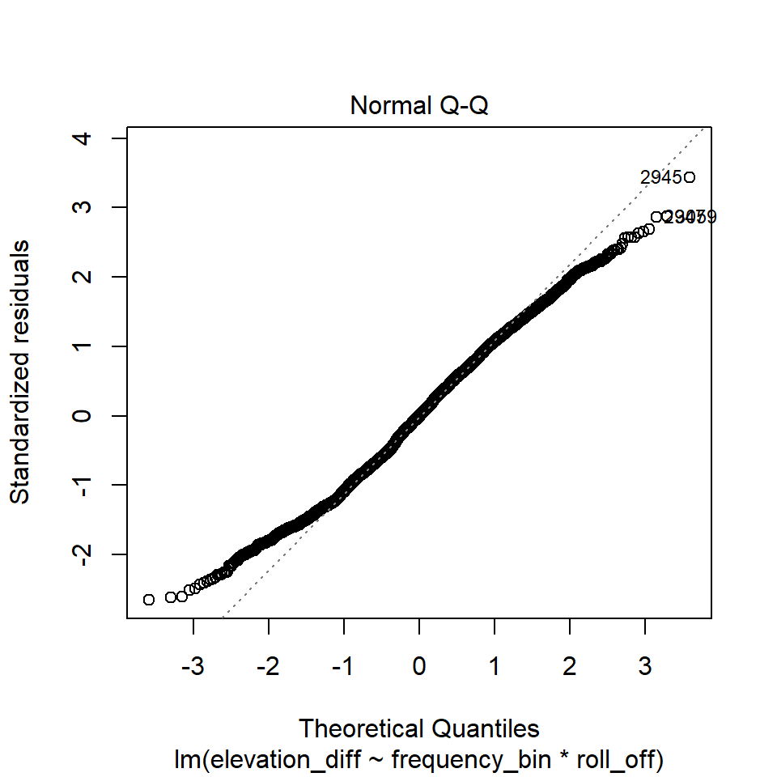

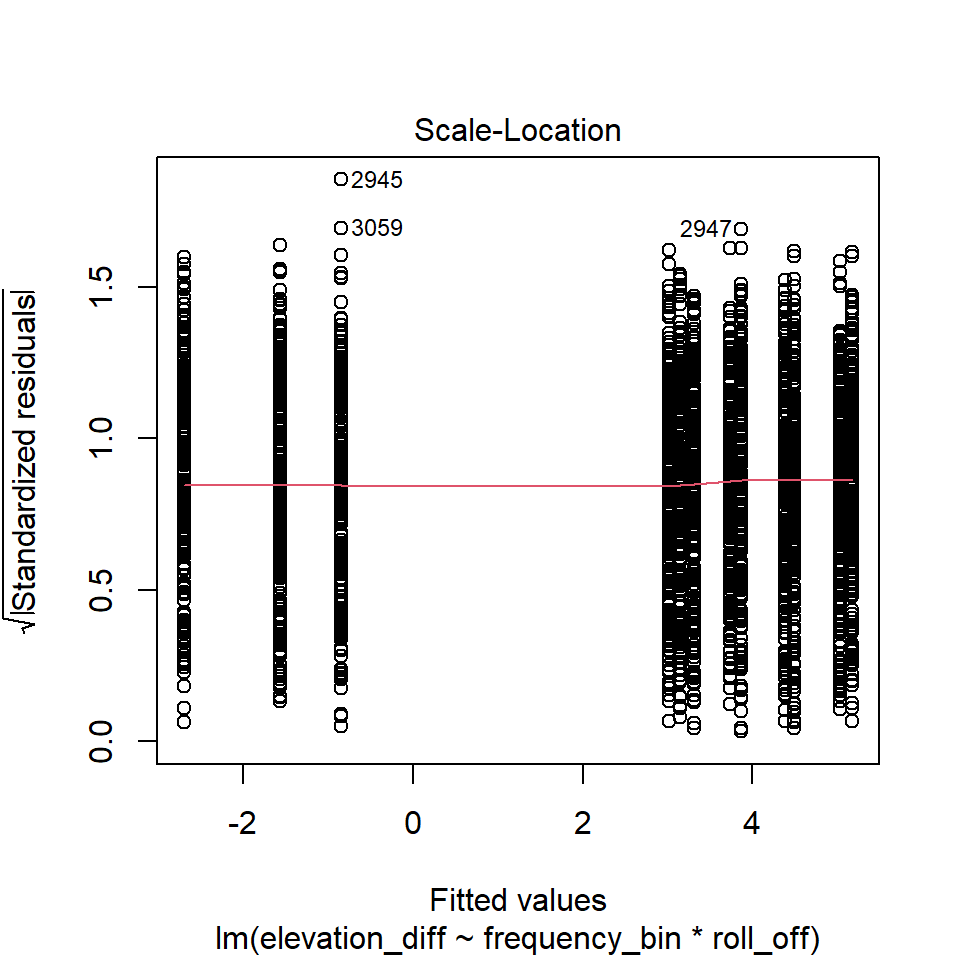

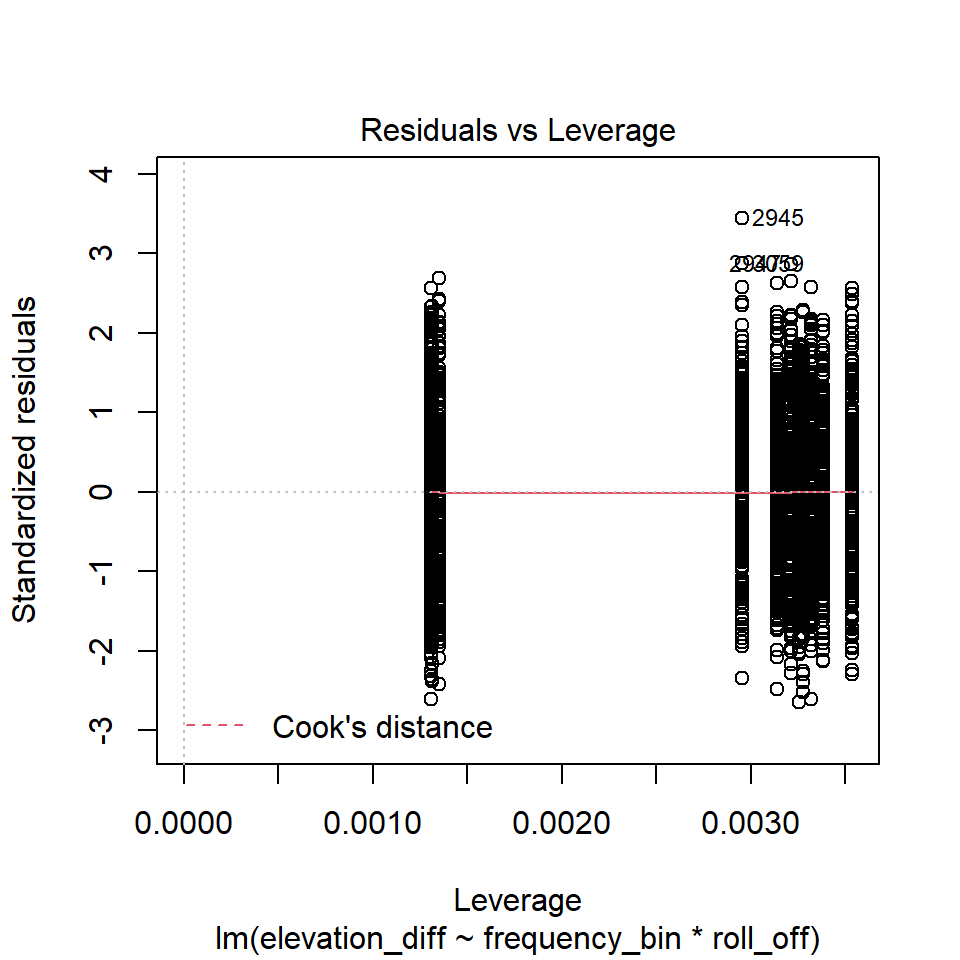

```r
#diagnostic plots-time:
plot(ancova.flute_ele_freqXroll_off)
```

```r
#normal distribution is a little funky
```

More Stats:

```r
#ANOVA:
anova(ancova.flute_ele_freqXroll_off)
```

```
## Analysis of Variance Table
##
## Response: elevation_diff
##                          Df  Sum Sq Mean Sq F value    Pr(>F)
## frequency_bin             3   19614  6538.0 18.3892 8.019e-12 ***
## roll_off                  1     790   790.2  2.2224    0.1361
## frequency_bin:roll_off    3     102    33.9  0.0953    0.9627
## Residuals              3053 1085446   355.5
## ---
## Signif. codes:  0 '***' 0.001 '**' 0.01 '*' 0.05 '.' 0.1 ' ' 1
```

```r
#Post-Hoc:
emtrends(ancova.flute_ele_freqXroll_off,
         pairwise~frequency_bin, var="roll_off")
```

```
## $emtrends
##  frequency_bin roll_off.trend      SE   df lower.CL upper.CL
##  208                  0.00478 0.00426 3053 -0.00357   0.0131
##  554                  0.00233 0.01300 3053 -0.02315   0.0278
##  1480                 0.00764 0.00976 3053 -0.01149   0.0268
##  3951                 0.00285 0.00367 3053 -0.00434   0.0100
##
## Confidence level used: 0.95
##
## $contrasts
##  contrast                               estimate      SE   df t.ratio p.value
##  frequency_bin208 - frequency_bin554    0.002451 0.01370 3053   0.179  0.9980
##  frequency_bin208 - frequency_bin1480  -0.002861 0.01060 3053  -0.269  0.9932
##  frequency_bin208 - frequency_bin3951   0.001927 0.00562 3053   0.343  0.9861
##  frequency_bin554 - frequency_bin1480  -0.005312 0.01620 3053  -0.327  0.9879
##  frequency_bin554 - frequency_bin3951  -0.000524 0.01350 3053  -0.039  1.0000
##  frequency_bin1480 - frequency_bin3951  0.004788 0.01040 3053   0.459  0.9678
##
## P value adjustment: tukey method for comparing a family of 4 estimates
```

#### Results (Flute)

Anova-table: First statistics tell us, that the Pratts Effect is generally given (p= 8.019e-12 ***). It also tells us that spectral roll-off does not predict differences in elevation (p= 0.1361) for the flute tones either, neither there is an interaction with frequency_bin (p= 0.9627).

emtrends and emmeans-tables: The Post-Hoc results indicate, that if roll-off of a tone was to predict elevation differences, within each frequency_bin, there would be a positive relation (higher spectral roll-off results in higher elevation differences). However, we have no significance for any of those, so we can conclude: For our flute tones, the spectral roll-off does not influence the presence and strength of the Pratts Effect either.

Interaction-plot:

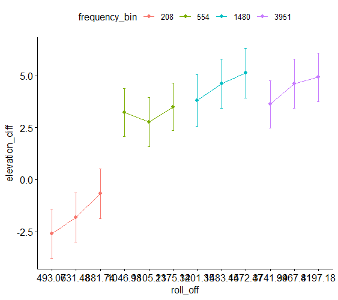

Interaction Plot

```r
#for visual presentation:
interaction_plot_flute_roll_off <-
  ggline(data_group1_flute, x = "roll_off", y = "elevation_diff", color = "frequency_bin",
       add = c("mean_se"))
```